# シミュレーション例 2

Ryoji Yukihiro

2026-05-21

この例では，一つの因子モデルに対して，複数のサンプルサイズを指定して，シミュレーション結果を比較します。

## 初期設定

使用するpackageを読み込みます。 また，シミュレートしたデータファイルを保存する作成するディレクトリーを指定します。

```r
library(psych)
library(simefa)
ddir <- "./simdata"  # シミュレーションのデータ保存ディレクトリ
```

## 因子モデルの定義

母集団の因子モデルとして，3因子11項目の因子負荷量行列と，因子間相関行列を指定します。

```r
nfac <- 3  # 因子数
nvar <- 11 # 変数の数
fload <- matrix(  # 母集団因子負荷量の定義
  c(
    .8,  0,  0,
    .7,  0,  0,
    .6,  0,  0,
    .5,  0,  0,
    0, .7,  0,
    0, .6,  0,
    0, .5,  0,
    0, .4,  0,
    0,  0, .6,
    0,  0, .5,
    0,  0, .4),
  nvar, nfac,byrow=TRUE)

fcor <- matrix(  # 因子間相関の定義
  c(1, .5, .3,
    .5, 1, .4,
    .3, .4, 1), nfac, nfac)

#factor_model(fload, fcor) # 共通性，独自性，因子寄与等を確認
```

## シミュレーションの実行

サンプルサイズを5水準(N=50, 100, 200, 500, 1000)変化させ，シミュレーションを実行してみます。 シミュレーション回数は条件ごとに100回としています。できれば，シミュレーション回数はもっと多い方がよいでしょうが，その分実行時間も長くなります。

Windows以外では，run_multiple_efa_sim()関数で multicore=TRUE とオプションを指定すると，CPUの複数コアを使用して並列計算を行いますので計算が速くなります。Mac，Linux，およびWindows環境でもWLS上であれば並列計算が可能です。

```r
set.seed(123) # 乱数のシードを固定
# サンプルサイズを複数指定して，シミュレーション結果を比較
set.seed(123) # 乱数のシードを固定
datafiles <- gen_multiple_efa_data(fload, fcor, ss=c(50,100,200,500,1000), nrep=100, ddir) # サンプルサイズを5水準設定し，因子モデルからデータを生成
simresult2 <- run_multiple_efa_sim(fload, fcor, datafiles, rotation="oblimin") # データを分析し，結果を整理
summary(simresult2) # シミュレーション結果の要約を出力
```

```
## N of Replications: 100
## Sample Size: 50 100 200 500 1000
##
## Congruence Coefficients(K):
##      Average    SD    5%   50%   95%
## 50     0.791 0.119 0.556 0.828 0.928
## 100    0.881 0.087 0.641 0.905 0.958
## 200    0.934 0.073 0.856 0.951 0.979
## 500    0.981 0.013 0.964 0.984 0.991
## 1000   0.992 0.004 0.986 0.993 0.996
##
## Discrepancies(D):
##      Average    SD    5%   50%   95%
## 50     0.215 0.055 0.138 0.202 0.325
## 100    0.154 0.045 0.101 0.144 0.269
## 200    0.109 0.040 0.066 0.102 0.165
## 500    0.060 0.015 0.045 0.057 0.082
## 1000   0.040 0.008 0.029 0.039 0.055
##
## Variability of Factor Solutions(V):
##      Average    SD    5%   50%   95%
## 50     0.208 0.048 0.147 0.194 0.294
## 100    0.148 0.040 0.104 0.141 0.252
## 200    0.106 0.038 0.070 0.097 0.161
## 500    0.059 0.014 0.045 0.057 0.078
## 1000   0.039 0.008 0.029 0.038 0.052
```

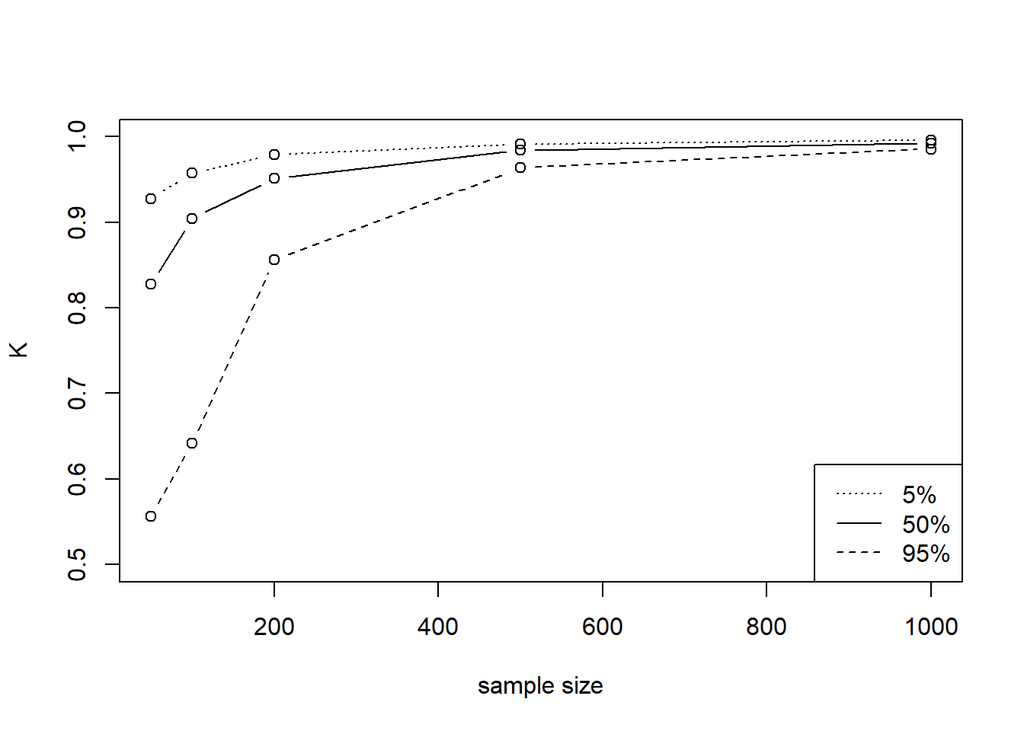

```r
plot(simresult2) # 一致係数Kをプロット
```

$K$, $D$, $V$はシミュレーション例1と同じものです。summaryで要約が出力され，plotで$K$のプロットが得られます。

この結果をみると，この因子構造の場合はN=200ではサンプルサイズがやや不足のようです。N=500では$K$も良い値が得られていますので，N=300, 400あたりを調べて見る必要がありそうです。

各因子の項目数が多い場合や，項目の因子負荷量がより大きい場合では，この例より小さなサンプルサイズでも高い$K$が得られるはずですので，試してもらうとよいでしょう。

（戻る）